# IODS course project

# Logistic regression

## Reading the joined data from the local folder

```r
# reading the data from a local folder

library(readr)
alc <- read.csv("data/joined_alc_data.csv")
```

## Exploration of the data

Original data source: https://www.archive.ics.uci.edu/dataset/320/student+performance

The data consist of information on secondary education student performance in Portugal. The data is joined from two data sets

```r
# Exploration of the data variables

str(alc)
```

```
## 'data.frame':    370 obs. of  35 variables:
##  $ school    : chr  "GP" "GP" "GP" "GP" ...
##  $ sex       : chr  "F" "F" "F" "F" ...
##  $ age       : int  18 17 15 15 16 16 16 17 15 15 ...
##  $ address   : chr  "U" "U" "U" "U" ...
##  $ famsize   : chr  "GT3" "GT3" "LE3" "GT3" ...
##  $ Pstatus   : chr  "A" "T" "T" "T" ...
##  $ Medu      : int  4 1 1 4 3 4 2 4 3 3 ...
##  $ Fedu      : int  4 1 1 2 3 3 2 4 2 4 ...
##  $ Mjob      : chr  "at_home" "at_home" "at_home" "health" ...
##  $ Fjob      : chr  "teacher" "other" "other" "services" ...
##  $ reason    : chr  "course" "course" "other" "home" ...
##  $ guardian  : chr  "mother" "father" "mother" "mother" ...
##  $ traveltime: int  2 1 1 1 1 1 1 2 1 1 ...
##  $ studytime : int  2 2 2 3 2 2 2 2 2 2 ...
```

[output cut: 21 more lines]

```r
colnames(alc)
```

```
##  [1] "school"     "sex"        "age"        "address"    "famsize"
##  [6] "Pstatus"    "Medu"       "Fedu"       "Mjob"       "Fjob"
## [11] "reason"     "guardian"   "traveltime" "studytime"  "schoolsup"
## [16] "famsup"     "activities" "nursery"    "higher"     "internet"
## [21] "romantic"   "famrel"     "freetime"   "goout"      "Dalc"
## [26] "Walc"       "health"     "failures"   "paid"       "absences"
## [31] "G1"         "G2"         "G3"         "alc_use"    "high_use"
```

- The data set has 370 observations and 35 variables.
  - There are character, intgrer and logical variables in the data
  - The variables give information on, e.g., students background, school performance in maths and Portuguese (test scores ‘G1’, ‘G2’, and final grade ‘G3’) and alcohol consumption
- The students are between 15-22 years of age.

The dependent binary variable ‘high_use’ is when the mean of ‘Dalc’ and ‘Walc’ > 2 * ‘Dalc’ - workday alcohol consumption numeric: from 1 - very low to 5 - very high) * ‘Walc’ - weekend alcohol consumption (numeric: from 1 - very low to 5 - very high)

In this analysis we will use logistic regression to test the relationship of four chosen background variables with the binary dependent variable ‘high_use’.

## Choosing the variables

- The variables:
  1. ‘school’ student’s school (binary: ‘GP’ - Gabriel Pereira or ‘MS’ - Mousinho da Silveira)
  2. ‘famrel’ quality of family relationships (numeric: from 1 - very bad to 5 - excellent)
  - actually an ordinal variable, categories with a clear order
  3. ‘studytime’ - weekly study time (numeric: 1 - <2 hours, 2 - 2 to 5 hours, 3 - 5 to 10 hours, or 4 - >10 hours)
  - also an ordinal variable
  4. ‘G3’ final grade (numeric: from 0 to 20, output target)

## Hypothesis:

The hypothesis for the variables:

- ‘school’ no effect, similar distributions.
  - The effect of school could still be there and affect the model so should be ruled out.
- ‘famrel’ family relationship negatively correlated with high alcohol use
  - better family relationship -> more time spent with family -> less alcohol consumption?
- ‘studytime’ could negatively correlate with high alcohol use - less time for drinking…
- ‘G3’ better final score could be negatively correlated with high use

## Exploration of the variable distributions

The distribution between the high and low alcohol use students:

```r
# Distribution of 'high_use' in the data set:
table(alc$high_use)
```

```
##
## FALSE  TRUE
##   259   111
```

There are over twice as many “low alcohol use” students than “high use” students in the data set.

## The distributions of the variables:

First, the variables ‘famrel’ and ‘studytime’ need to be changed to be categorical.

- (I think the variables should be ordinal so I used “ordered” function first, but that gave me some wonky results in the model that did not make sense to me… “factor” function seems to work better)
- I also added labels, the labels 2-4 in ‘famrel’ are made up as I did not find the exact wording…

```r
# Changing 'famrel' into factors and adding labels
alc$famrel <- factor(alc$famrel, labels = c(" very bad", " bad", " ok", " good", " excellent"))

levels(alc$famrel)
```

```
## [1] " very bad"  " bad"       " ok"        " good"      " excellent"
```

```r
# Changing 'studytime' into factors and adding labels
alc$studytime <- factor(alc$studytime, labels = c(" <2 hours", " 2 to 5 hours", " 5 to 10 hours", " >10 hours"))
```

Then we can see the overview of the chosen variables:

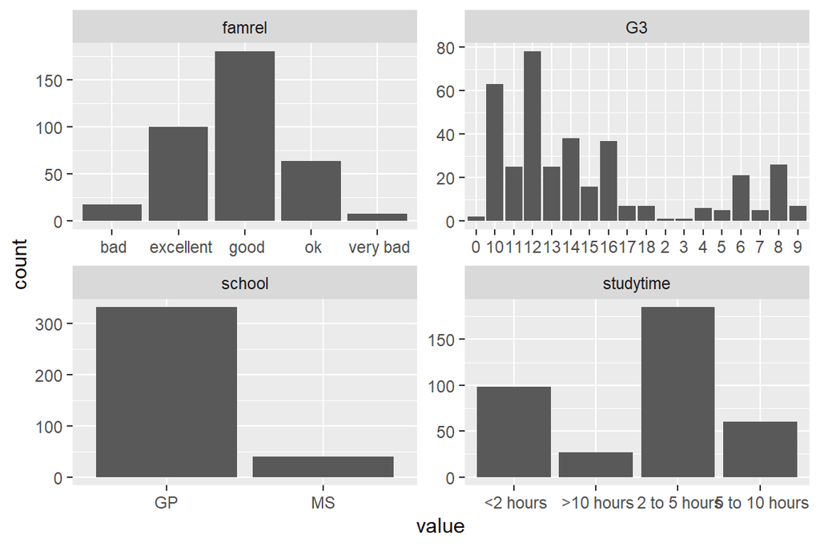

```r
# access the tidyverse libraries tidyr, dplyr, ggplot2
library(tidyr); library(dplyr); library(ggplot2)

# selecting the variables of interest
filtered_alc <- alc %>% select(school, famrel, studytime, G3)

# a bar plot of the variables
gather(filtered_alc) %>% ggplot(aes(value)) + facet_wrap("key", scales = "free") + geom_bar()
```

```r
# summaries of the variables
summary(filtered_alc)
```

```
##     school                 famrel             studytime         G3
##  Length:370          very bad :  8    <2 hours     : 98   Min.   : 0.00
##  Class :character    bad      : 18    2 to 5 hours :185   1st Qu.:10.00
##  Mode  :character    ok       : 64    5 to 10 hours: 60   Median :12.00
##                      good     :180    >10 hours    : 27   Mean   :11.52
##                      excellent:100                        3rd Qu.:14.00
##                                                           Max.   :18.00
```

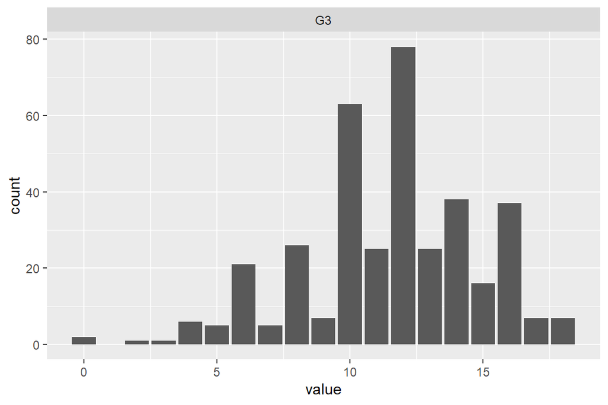

```r
# G3 looks very odd, lets make a separate plot for it...
G3_test <- alc %>% select(G3)

gather(G3_test) %>% ggplot(aes(value)) + facet_wrap("key", scales = "free") + geom_bar()
```

```r
# now it looks ok, go figure..
```

The variables on the plots are in a weird order and I cant fix that… Maybe it is the gather function

Next, the distribution of each of the variables in relation to alcohol use:

### School and alcohol

- Barplots and crosstables to see whether the schools have different amounts of ‘high_use’ students:

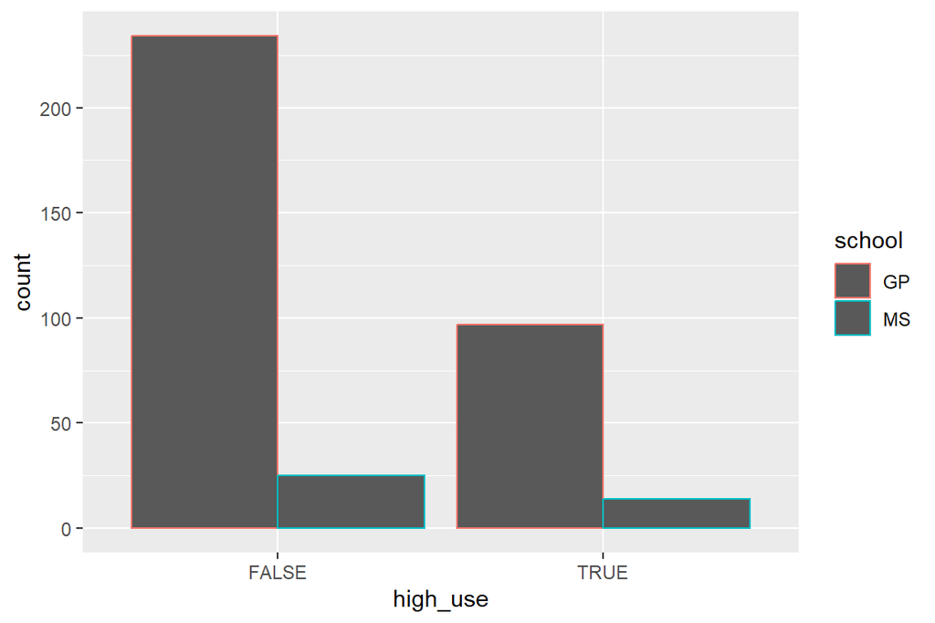

```r
# initialize a plot of high_use
g1 <- ggplot(data = alc, aes(x = high_use, col = school))

# drawing the bar plot
g1 + geom_bar(position = "dodge")
```

```r
# looking at a crosstable to see exact numbers:
school_tab <- table(high_use = alc$high_use, alc$school)

# a crostable using percentages:
alc_with_percentages <- prop.table(school_tab, 2) * 100

table(high_use = alc$high_use, alc$school)
```

```
##
## high_use  GP  MS
##    FALSE 234  25
##    TRUE   97  14
```

```r
alc_with_percentages
```

```
##
## high_use       GP       MS
##    FALSE 70.69486 64.10256
##    TRUE  29.30514 35.89744
```

GP (Gabriel Pereira) is a larger school (or had more respondents or participants in the survey) than MS (Mousinho da Silveira). MS had higher proportion of ‘high_use’, but the sample sizes are very different.

### Family relations and high alcohol use

Bar plots for values and then percentages:

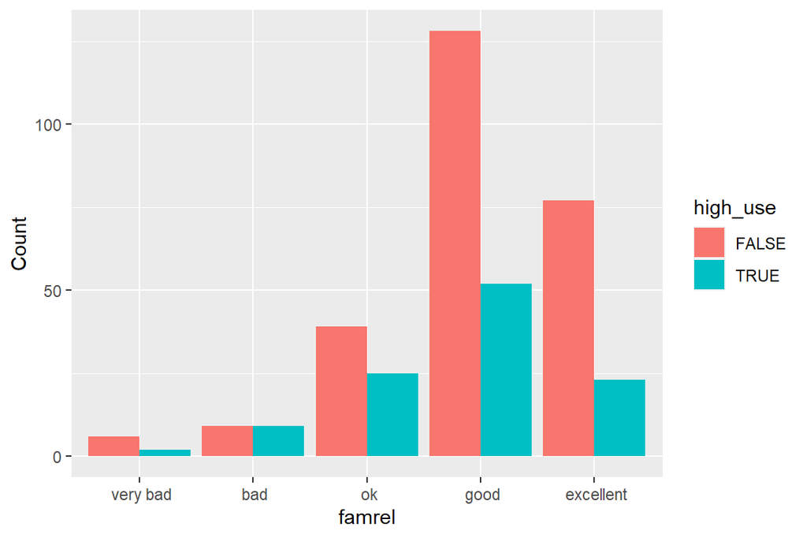

```r
# Create the bar plot with values
ggplot(alc, aes(x = famrel, fill = as.factor(high_use))) +
  geom_bar(position = "dodge") +
  labs(x = "famrel", y = "Count", fill = "high_use")
```

```r
# Calculate the percentages and counts for each category
famrel_summary <- alc %>%
  group_by(famrel, high_use) %>%
  summarise(count = n()) %>%
  mutate(perc = count / sum(count))
```

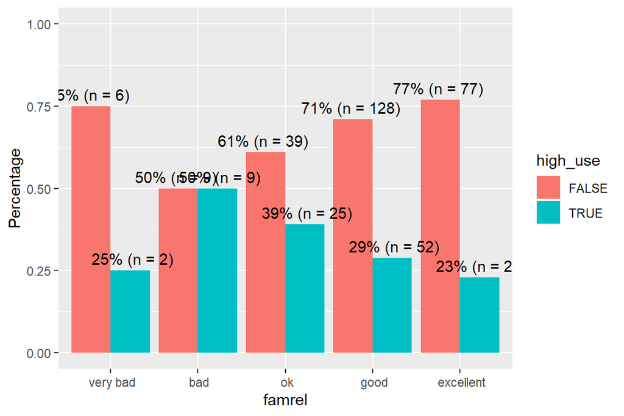

```r
# Create the bar plot with percentages and n
ggplot(famrel_summary, aes(x = famrel, y = perc, fill = as.factor(high_use))) +
  geom_bar(stat = "identity", position = "dodge") +
  geom_text(aes(label = paste0(round(perc*100), "% (n = ", count, ")")),
            position = position_dodge(width = 1), vjust = -0.5) +
  labs(x = "famrel", y = "Percentage", fill = "high_use") +
  ylim(0, 1)
```

It would appear that proportion of high use decreases when the reported family relations improve. There does seem to be lower proportion of high alcohol use in students who reported extremely poor family relationships. However, there are very few students in the very poor ‘famrel’ category.

The same data in a table form:

```r
# table with high alcohol use and family relations

famrel_tab <- table(high_use = alc$high_use, alc$famrel)

# adding percentages:

famreltab_with_percentages <- prop.table(famrel_tab, 2) * 100

table(high_use = alc$high_use, alc$famrel)
```

```
##
## high_use  very bad  bad  ok  good  excellent
##    FALSE         6    9  39   128         77
##    TRUE          2    9  25    52         23
```

```r
famreltab_with_percentages
```

```
##
## high_use  very bad      bad       ok     good  excellent
##    FALSE  75.00000 50.00000 60.93750 71.11111   77.00000
##    TRUE   25.00000 50.00000 39.06250 28.88889   23.00000
```

### Study time and alcohol use

Bar plots for values and then percentages:

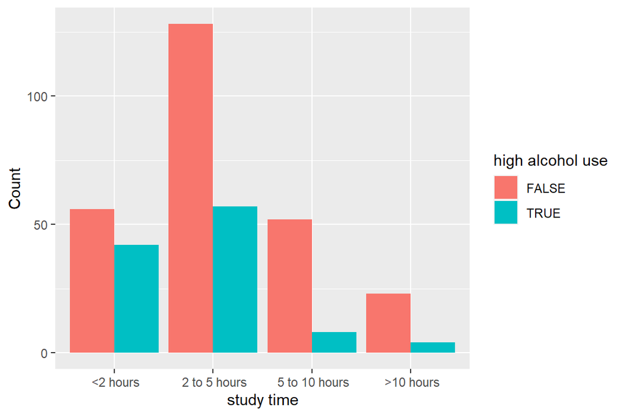

```r
# Create the bar plot with values
ggplot(alc, aes(x = studytime, fill = as.factor(high_use))) +
  geom_bar(position = "dodge") +
  labs(x = "study time", y = "Count", fill = "high alcohol use")
```

```r
# Calculate the percentages and counts for each category
studytime_summary <- alc %>%
  group_by(studytime, high_use) %>%
  summarise(count = n()) %>%
  mutate(perc = count / sum(count))
```

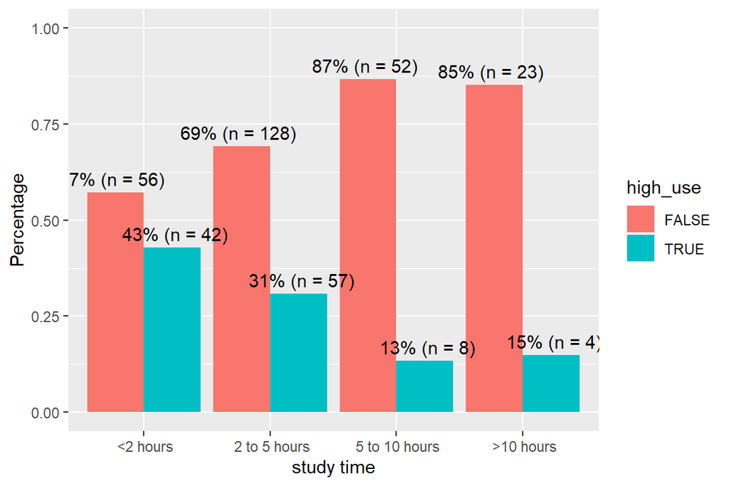

```r
# Create the bar plot with percentages and n
ggplot(studytime_summary, aes(x = studytime, y = perc, fill = as.factor(high_use))) +
  geom_bar(stat = "identity", position = "dodge") +
  geom_text(aes(label = paste0(round(perc*100), "% (n = ", count, ")")),
            position = position_dodge(width = 1), vjust = -0.5) +
  labs(x = "study time", y = "Percentage", fill = "high_use") +
  ylim(0, 1)
```

Based on the bar plot, it does seem that ‘studytime’ is indeed negatively correlated with ‘high_use’

The same data in a table form:

```r
# table with high alcohol use and study time

studytime_tab <- table(high_use = alc$high_use, alc$studytime)

# adding percentages:

studytimetab_with_percentages <- prop.table(studytime_tab, 2) * 100

table(high_use = alc$high_use, alc$studytime)
```

```
##
## high_use  <2 hours  2 to 5 hours  5 to 10 hours  >10 hours
##    FALSE        56           128             52         23
##    TRUE         42            57              8          4
```

```r
studytimetab_with_percentages
```

```
##
## high_use  <2 hours  2 to 5 hours  5 to 10 hours  >10 hours
##    FALSE  57.14286      69.18919       86.66667   85.18519
##    TRUE   42.85714      30.81081       13.33333   14.81481
```

### Final test result (G3) and high alcohol use

We create a boxplot for the to illustrate the potential relationship between final test results (numeric variable) and high alcohol use:

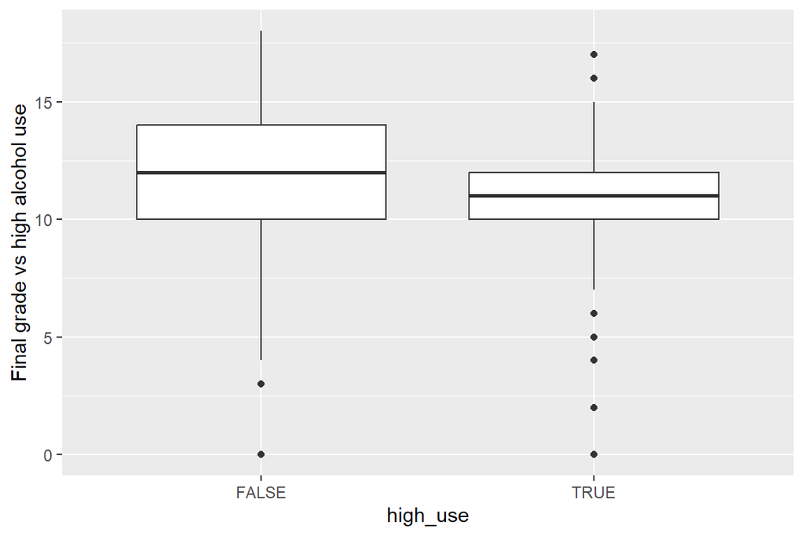

```r
# initialize a plot of high_use and G3
g1 <- ggplot(alc, aes(x = high_use, y = G3))

# define the plot as a boxplot and draw it
g1 + geom_boxplot() + ylab("Final grade vs high alcohol use")
```

There does not seem to be much of an effect of high alcohol use on final grade (‘G3’).

## Statistical analysis

Creating the model with the chosen variables:

- ‘school’
- ‘famrel’
- ‘studytime’
- ‘G3’

Creating and printing the model:

```r
# find the model with glm()
m <- glm(high_use ~ school + famrel + studytime + G3, data = alc, family = "binomial")

# print out a summary of the model
summary(m)
```

```
##
## Call:
## glm(formula = high_use ~ school + famrel + studytime + G3, family = "binomial",
##     data = alc)
##
## Coefficients:
##                         Estimate Std. Error z value Pr(>|z|)
## (Intercept)              0.09027    0.96477   0.094  0.92545
## schoolMS                 0.09774    0.37929   0.258  0.79665
## famrel bad               0.96006    0.96890   0.991  0.32175
## famrel ok                0.58415    0.88300   0.662  0.50826
## famrel good              0.21688    0.85937   0.252  0.80075
## famrel excellent        -0.12296    0.87775  -0.140  0.88859
## studytime 2 to 5 hours  -0.45606    0.26678  -1.709  0.08736 .
## studytime 5 to 10 hours -1.43196    0.43962  -3.257  0.00113 **
## studytime >10 hours     -1.36219    0.59211  -2.301  0.02142 *
## G3                      -0.06041    0.03673  -1.645  0.10003
## ---
## Signif. codes:  0 '***' 0.001 '**' 0.01 '*' 0.05 '.' 0.1 ' ' 1
##
## (Dispersion parameter for binomial family taken to be 1)
##
##     Null deviance: 452.04  on 369  degrees of freedom
## Residual deviance: 422.56  on 360  degrees of freedom
## AIC: 442.56
##
## Number of Fisher Scoring iterations: 4
```

```r
# print out the coefficients of the model
coef(m)
```

```
##             (Intercept)                schoolMS              famrel bad
##              0.09027131              0.09773687              0.96006061
##               famrel ok             famrel good        famrel excellent
##              0.58414986              0.21688453             -0.12295941
##  studytime 2 to 5 hours studytime 5 to 10 hours     studytime >10 hours
##             -0.45606075             -1.43196021             -1.36218503
##                      G3
##             -0.06041110
```

The calculation of the odds ratios:

```r
# compute odds ratios (OR)
OR <- coef(m) %>% exp

# compute confidence intervals (CI)
CI <- confint(m) %>% exp
# print out the odds ratios with their confidence intervals
cbind(OR, CI)
```

```
##                                OR      2.5 %     97.5 %
## (Intercept)             1.0944712 0.13080942  6.6751067
## schoolMS                1.1026726 0.51291952  2.2911229
## famrel bad              2.6118548 0.42863806 22.1092159
## famrel ok               1.7934656 0.35434586 13.3845382
## famrel good             1.2422007 0.25855541  8.9733484
## famrel excellent        0.8842996 0.17649602  6.5482380
## studytime 2 to 5 hours  0.6337753 0.37558562  1.0709740
## studytime 5 to 10 hours 0.2388403 0.09508293  0.5427036
## studytime >10 hours     0.2561006 0.06964312  0.7490803
## G3                      0.9413775 0.87536281  1.0113400
```

- With ‘famrel’ the lack of significance could be because the reference category ‘famrel very bad’ had only a few students in it and is not reliable…
- The only confidence intervals that do not include 1 are ‘studytime 5 to 10 hours’ and ‘studytime >10 hours’.
  - ‘studytime’ is significantly correlated with ‘high_use’, this is consistent with the significance values in the previous table
- Based on the odds ratios, for example, for students in ‘studytime > 10 hours’ category have 0.26 times lower odds to be in the high_use category as those with ‘studytime < 2 hours’

## The predictive power of the model

```r
# fit the model
m_studytime <- glm(high_use ~ studytime, data = alc, family = "binomial")

# predict() the probability of high_use
probabilities <- predict(m, type = "response")

library(dplyr)
# add the predicted probabilities to 'alc'
alc <- mutate(alc, probability = probabilities)

# use the probabilities to make a prediction of high_use
alc <- mutate(alc, prediction = c(probability > 0.5))

# see the last ten original classes, predicted probabilities, and class predictions
select(alc, studytime, high_use, probability, prediction) %>% tail(10)
```

```
##          studytime high_use probability prediction
## 361   2 to 5 hours    FALSE   0.3022698      FALSE
## 362       <2 hours    FALSE   0.5998626       TRUE
## 363       <2 hours     TRUE   0.4860603      FALSE
## 364  5 to 10 hours    FALSE   0.1098920      FALSE
## 365       <2 hours    FALSE   0.4804110      FALSE
## 366  5 to 10 hours    FALSE   0.1585620      FALSE
## 367   2 to 5 hours    FALSE   0.3151608      FALSE
## 368   2 to 5 hours    FALSE   0.3752646      FALSE
## 369       <2 hours     TRUE   0.5896998       TRUE
## 370       <2 hours     TRUE   0.4503595      FALSE
```

```r
# tabulate the target variable versus the predictions
table(high_use = alc$high_use, alc$prediction)
```

```
##
## high_use FALSE TRUE
##    FALSE   246   13
##    TRUE    100   11
```

Based on the matrix the model provided:

- 246 true negatives
- 11 true positives
- 13 false positives
- 100 false negatives

The model does not seem to predict very well. It highly underestimates the high alcohol use, giving high number of false negatives.

The guessing (hypothesises) were in line with the distributions of the variables in high and low use categories. However, the model does not indicate that ‘famrel’ is significantly correlated with high alcohol use. ‘school’ and ‘G3’ did not indicate a large effect at any point of data exploration.

# Clustering and classification

## Loading the “Boston” data

The “Boston” dataset is derived from U.S. census information on housing values in the suburbs of Boston Massachusetts. It is included in the ‘MASS’ library in R.

```r
# access the MASS package which has the data
library(MASS)
# loading the data
data("Boston")

# exploring the data
str(Boston)
```

```
## 'data.frame':    506 obs. of  14 variables:
##  $ crim   : num  0.00632 0.02731 0.02729 0.03237 0.06905 ...
##  $ zn     : num  18 0 0 0 0 0 12.5 12.5 12.5 12.5 ...
##  $ indus  : num  2.31 7.07 7.07 2.18 2.18 2.18 7.87 7.87 7.87 7.87 ...
##  $ chas   : int  0 0 0 0 0 0 0 0 0 0 ...
##  $ nox    : num  0.538 0.469 0.469 0.458 0.458 0.458 0.524 0.524 0.524 0.524 ...
##  $ rm     : num  6.58 6.42 7.18 7 7.15 ...
##  $ age    : num  65.2 78.9 61.1 45.8 54.2 58.7 66.6 96.1 100 85.9 ...
##  $ dis    : num  4.09 4.97 4.97 6.06 6.06 ...
##  $ rad    : int  1 2 2 3 3 3 5 5 5 5 ...
##  $ tax    : num  296 242 242 222 222 222 311 311 311 311 ...
##  $ ptratio: num  15.3 17.8 17.8 18.7 18.7 18.7 15.2 15.2 15.2 15.2 ...
##  $ black  : num  397 397 393 395 397 ...
##  $ lstat  : num  4.98 9.14 4.03 2.94 5.33 ...
##  $ medv   : num  24 21.6 34.7 33.4 36.2 28.7 22.9 27.1 16.5 18.9 ...
```

In this assignment we will focus on the crime rate (‘crim’) as the dependent variable.

## Graphical overview of the data

Summaries to explore the variables:

```r
# summaries of the variables
summary(Boston)
```

```
##       crim                zn             indus            chas
##  Min.   : 0.00632   Min.   :  0.00   Min.   : 0.46   Min.   :0.00000
##  1st Qu.: 0.08205   1st Qu.:  0.00   1st Qu.: 5.19   1st Qu.:0.00000
##  Median : 0.25651   Median :  0.00   Median : 9.69   Median :0.00000
##  Mean   : 3.61352   Mean   : 11.36   Mean   :11.14   Mean   :0.06917
##  3rd Qu.: 3.67708   3rd Qu.: 12.50   3rd Qu.:18.10   3rd Qu.:0.00000
##  Max.   :88.97620   Max.   :100.00   Max.   :27.74   Max.   :1.00000
##       nox               rm             age              dis
##  Min.   :0.3850   Min.   :3.561   Min.   :  2.90   Min.   : 1.130
##  1st Qu.:0.4490   1st Qu.:5.886   1st Qu.: 45.02   1st Qu.: 2.100
##  Median :0.5380   Median :6.208   Median : 77.50   Median : 3.207
##  Mean   :0.5547   Mean   :6.285   Mean   : 68.57   Mean   : 3.795
##  3rd Qu.:0.6240   3rd Qu.:6.623   3rd Qu.: 94.08   3rd Qu.: 5.188
##  Max.   :0.8710   Max.   :8.780   Max.   :100.00   Max.   :12.127
##       rad              tax           ptratio          black
##  Min.   : 1.000   Min.   :187.0   Min.   :12.60   Min.   :  0.32
##  1st Qu.: 4.000   1st Qu.:279.0   1st Qu.:17.40   1st Qu.:375.38
##  Median : 5.000   Median :330.0   Median :19.05   Median :391.44
##  Mean   : 9.549   Mean   :408.2   Mean   :18.46   Mean   :356.67
##  3rd Qu.:24.000   3rd Qu.:666.0   3rd Qu.:20.20   3rd Qu.:396.23
##  Max.   :24.000   Max.   :711.0   Max.   :22.00   Max.   :396.90
##      lstat            medv
##  Min.   : 1.73   Min.   : 5.00
##  1st Qu.: 6.95   1st Qu.:17.02
##  Median :11.36   Median :21.20
##  Mean   :12.65   Mean   :22.53
##  3rd Qu.:16.95   3rd Qu.:25.00
##  Max.   :37.97   Max.   :50.00
```

Histograms to visualize the distributions of the different variables:

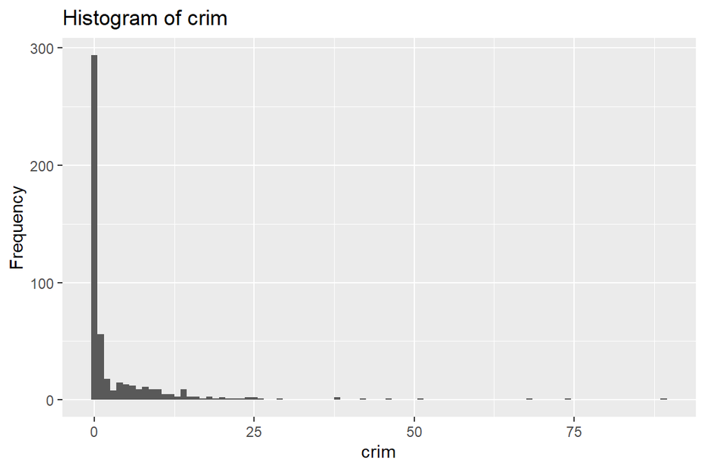

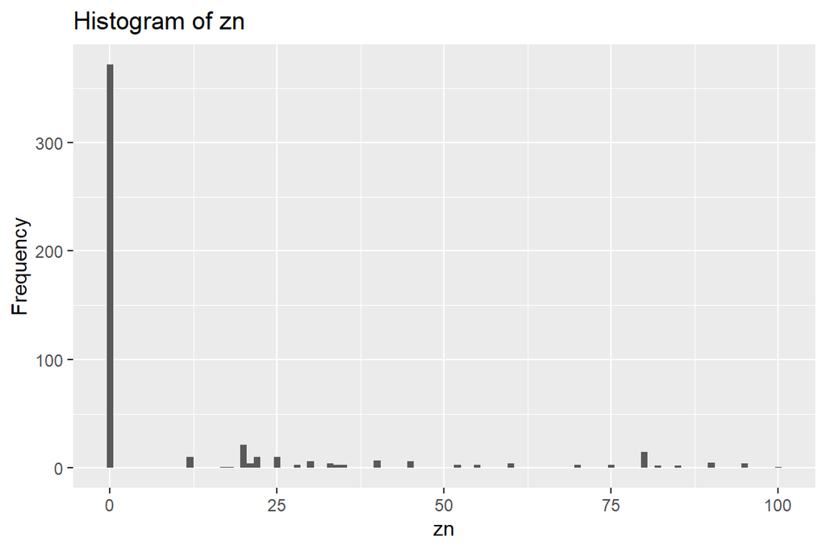

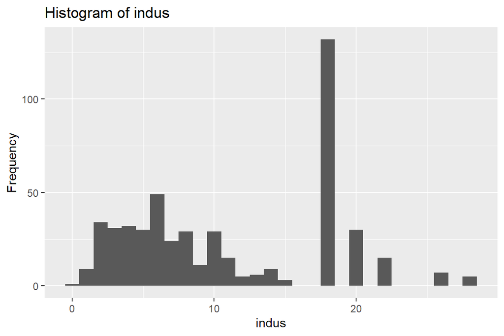

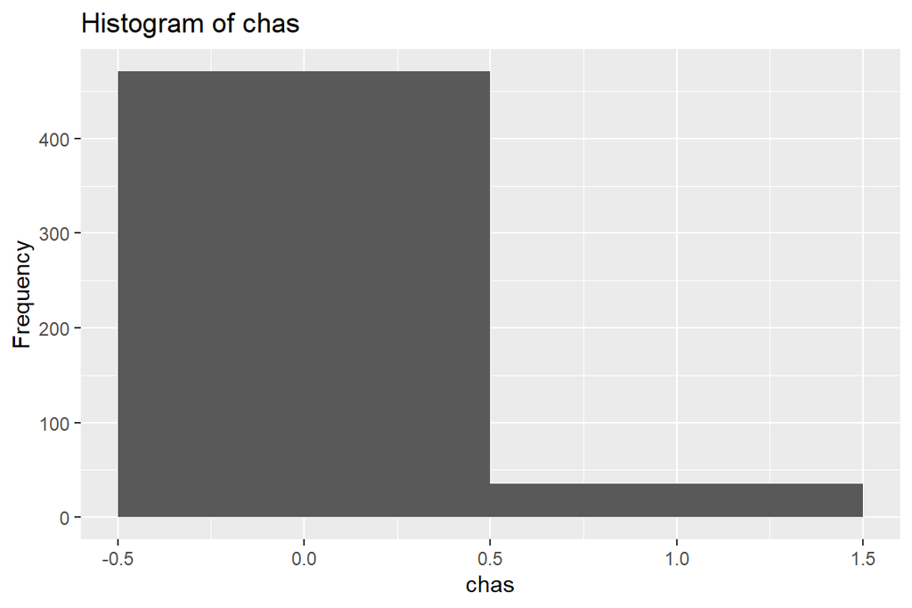

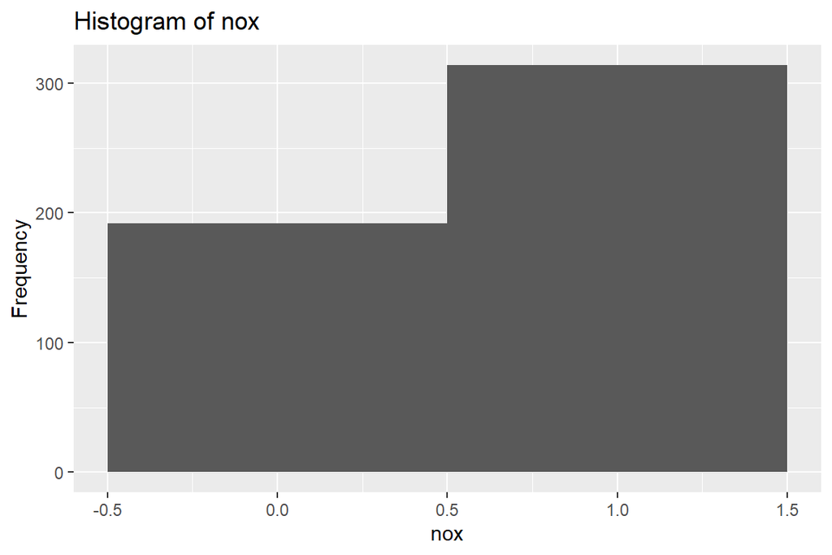

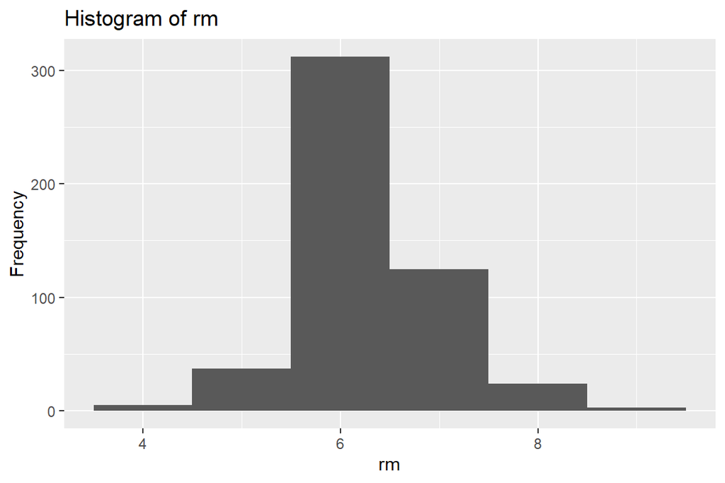

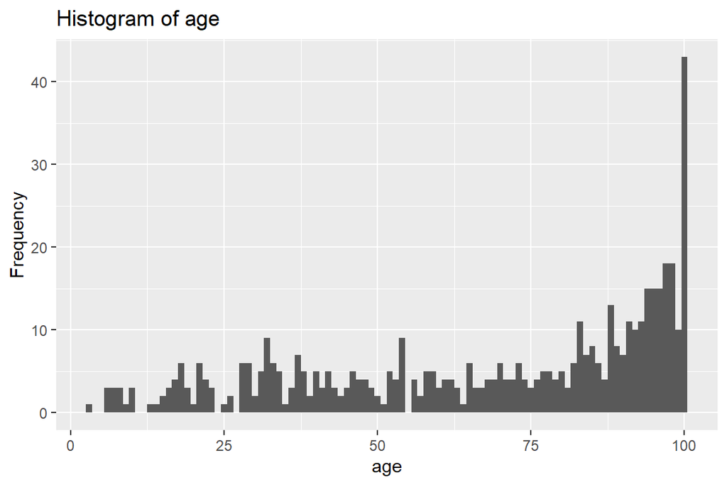

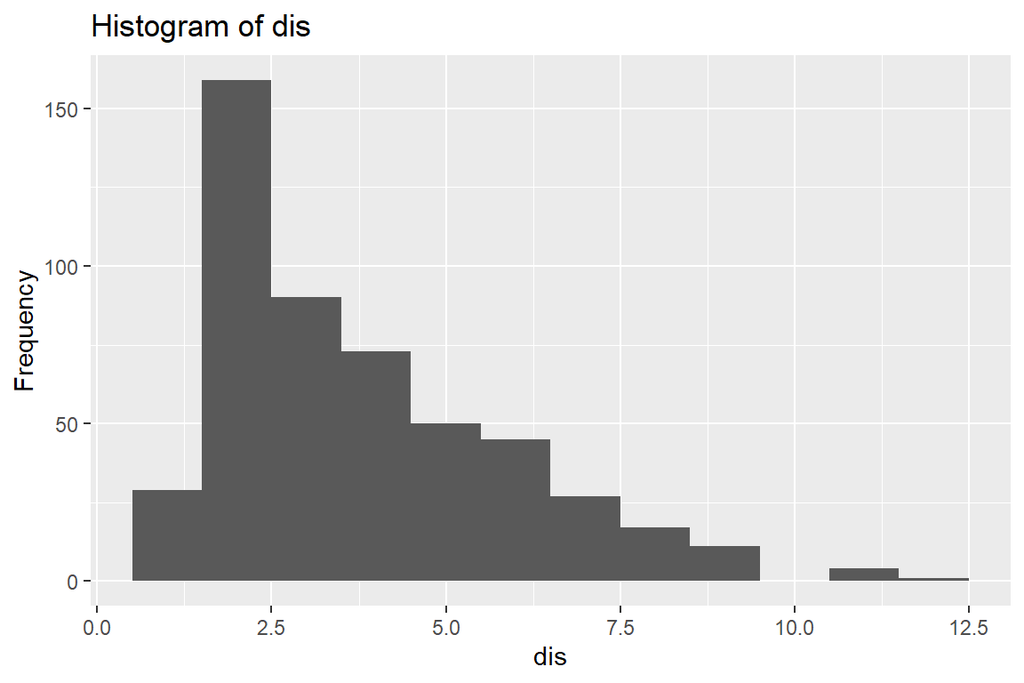

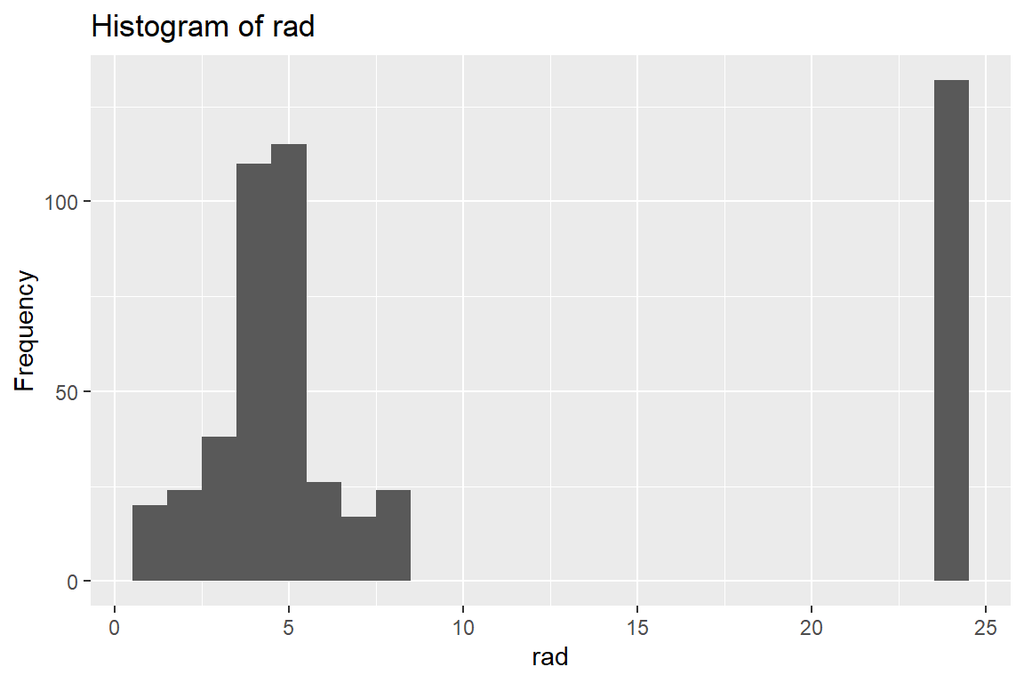

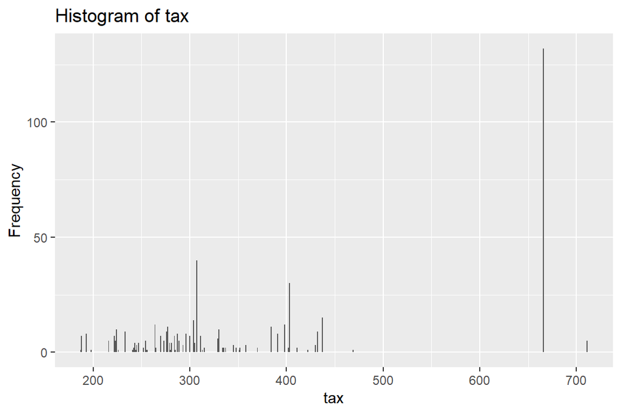

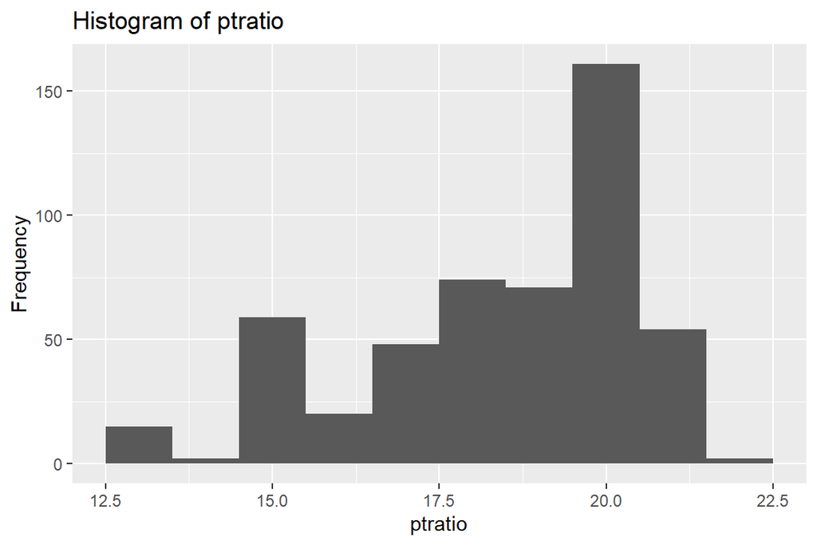

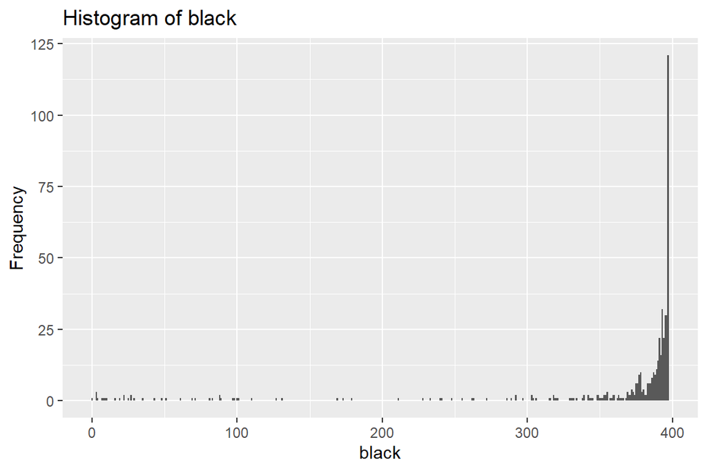

[2 more figures not shown]

```r
# Loading the library
library(ggplot2)

# Create a list of variable names
variables <- names(Boston)

# Loop through the variables and create a histogram for each one
for (var in variables) {
  # Create the histogram
  p <- ggplot(Boston, aes_string(x = var)) +
    geom_histogram(binwidth = 1) +
    labs(x = var, y = "Frequency", title = paste("Histogram of", var))

  # Print the histogram
  print(p)
}
```

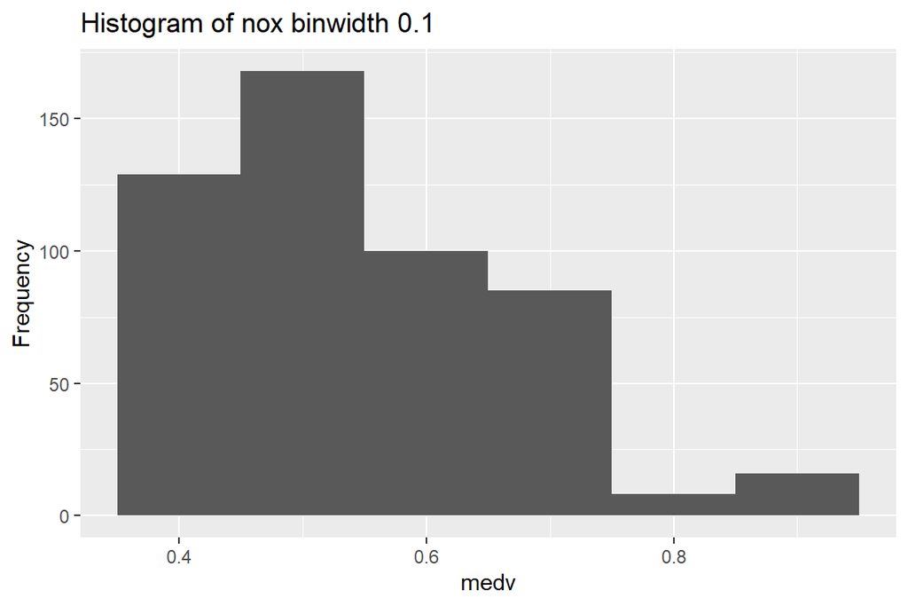

```r
# separate histogram for 'nox' as it is very poorly visualized with binwith of 1
 ggplot(Boston, aes(x = nox)) +
    geom_histogram(binwidth = 0.1) +
    labs(x = var, y = "Frequency", title = paste("Histogram of nox binwidth 0.1"))
```

Some general observations on variable distributions:

- The binwith 1 is probably not optimal for visualizing all of the variables but at least it shows something about every variable.
  - for nox a separate histogram with binwidth of 0.1
- The variables vary quite a bit regardign min/max and their distributions, very few are normally distributed (maybe only ‘rm’)
- ‘chas’ is a binary dummy variable

Some observations about individual variables:

- ‘crim’: Based on the histogram, most of the boroughs/ towns have a low crime rate, with a few with a very high crime rate. This is also reflected by the median being a lot lower than the mean.
- ‘zn’: most of the boroughs/towns have no residential land zoned for lots over 25,000 sq.ft.
- ‘age’: based on the data, there are a lot of districts, where all of the owner-occupied units were built before 1940.

The correlations between the variables can be visualized using corrplot function:

```r
# Graphical overview of the correlations in the data

# calculate the correlation matrix and round it
cor_matrix <- cor(Boston)

# print the correlation matrix
cor_matrix
```

```
##                crim          zn       indus         chas         nox
## crim     1.00000000 -0.20046922  0.40658341 -0.055891582  0.42097171
## zn      -0.20046922  1.00000000 -0.53382819 -0.042696719 -0.51660371
## indus    0.40658341 -0.53382819  1.00000000  0.062938027  0.76365145
## chas    -0.05589158 -0.04269672  0.06293803  1.000000000  0.09120281
## nox      0.42097171 -0.51660371  0.76365145  0.091202807  1.00000000
## rm      -0.21924670  0.31199059 -0.39167585  0.091251225 -0.30218819
## age      0.35273425 -0.56953734  0.64477851  0.086517774  0.73147010
## dis     -0.37967009  0.66440822 -0.70802699 -0.099175780 -0.76923011
## rad      0.62550515 -0.31194783  0.59512927 -0.007368241  0.61144056
## tax      0.58276431 -0.31456332  0.72076018 -0.035586518  0.66802320
## ptratio  0.28994558 -0.39167855  0.38324756 -0.121515174  0.18893268
## black   -0.38506394  0.17552032 -0.35697654  0.048788485 -0.38005064
## lstat    0.45562148 -0.41299457  0.60379972 -0.053929298  0.59087892
## medv    -0.38830461  0.36044534 -0.48372516  0.175260177 -0.42732077
##                  rm         age         dis          rad         tax    ptratio
## crim    -0.21924670  0.35273425 -0.37967009  0.625505145  0.58276431  0.2899456
## zn       0.31199059 -0.56953734  0.66440822 -0.311947826 -0.31456332 -0.3916785
## indus   -0.39167585  0.64477851 -0.70802699  0.595129275  0.72076018  0.3832476
## chas     0.09125123  0.08651777 -0.09917578 -0.007368241 -0.03558652 -0.1215152
## nox     -0.30218819  0.73147010 -0.76923011  0.611440563  0.66802320  0.1889327
## rm       1.00000000 -0.24026493  0.20524621 -0.209846668 -0.29204783 -0.3555015
## age     -0.24026493  1.00000000 -0.74788054  0.456022452  0.50645559  0.2615150
## dis      0.20524621 -0.74788054  1.00000000 -0.494587930 -0.53443158 -0.2324705
## rad     -0.20984667  0.45602245 -0.49458793  1.000000000  0.91022819  0.4647412
## tax     -0.29204783  0.50645559 -0.53443158  0.910228189  1.00000000  0.4608530
## ptratio -0.35550149  0.26151501 -0.23247054  0.464741179  0.46085304  1.0000000
## black    0.12806864 -0.27353398  0.29151167 -0.444412816 -0.44180801 -0.1773833
## lstat   -0.61380827  0.60233853 -0.49699583  0.488676335  0.54399341  0.3740443
## medv     0.69535995 -0.37695457  0.24992873 -0.381626231 -0.46853593 -0.5077867
##               black      lstat       medv
## crim    -0.38506394  0.4556215 -0.3883046
## zn       0.17552032 -0.4129946  0.3604453
## indus   -0.35697654  0.6037997 -0.4837252
## chas     0.04878848 -0.0539293  0.1752602
## nox     -0.38005064  0.5908789 -0.4273208
## rm       0.12806864 -0.6138083  0.6953599
## age     -0.27353398  0.6023385 -0.3769546
## dis      0.29151167 -0.4969958  0.2499287
## rad     -0.44441282  0.4886763 -0.3816262
## tax     -0.44180801  0.5439934 -0.4685359
## ptratio -0.17738330  0.3740443 -0.5077867
## black    1.00000000 -0.3660869  0.3334608
## lstat   -0.36608690  1.0000000 -0.7376627
## medv     0.33346082 -0.7376627  1.0000000
```

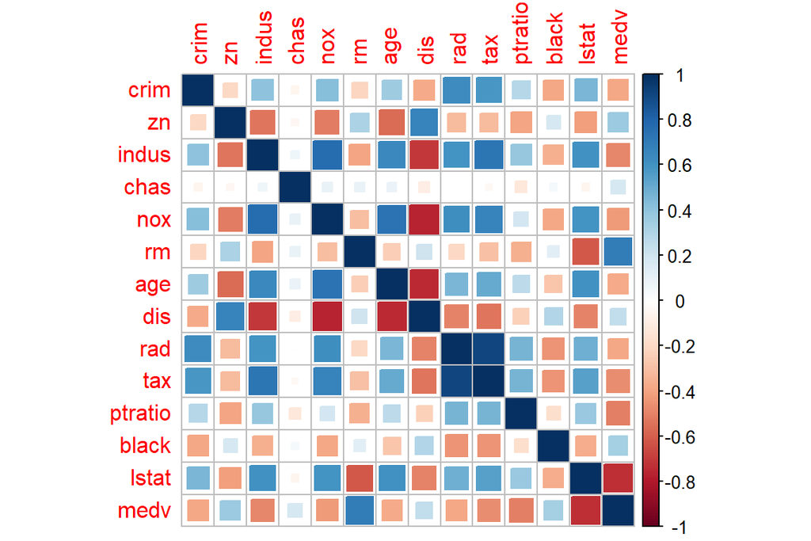

```r
# visualize the correlation matrix
library(corrplot)
corrplot(cor_matrix, method="square")
```

Some observations based on the correlation matrix:

Our dependent variable ‘crim’ (per capita crime rate by town): * crime rate (‘crim’) is positively highly correlated with ‘rad’ and ‘tax’ + higher property taxes are positively correlated with higher crime rate, meaning city centers? Positive correlation with distance from radial highways would also point to that. + ‘tax’ and ‘rad’ are also highly correlated with each other, so they might not be directly related to ‘crim’, but could be properties of city centres

Observations on some other variables:

- nitrogen gas emissions (‘nox’) are positively correlated with ‘ind’ (non-retail businesses) which makes sense
- ‘nox’ is also correlated with ‘tax’, caused by car emissions in city centre??
  - ‘nox’ also negatively correlated with ‘dis’ (distance from employment centres)
- ‘age’ is negatively correlated with ‘dis’ so newer houses in the suburbs?

The dataset is scaled using ‘scale’ function

- subtract the column means from the corresponding columns and divide the difference with standard deviation.

$$scaled(x) = \frac{x - mean(x)}{
sd(x)}$$

```r
# Summary of the dataset before scaling
summary(Boston)
```

```
##       crim                zn             indus            chas
##  Min.   : 0.00632   Min.   :  0.00   Min.   : 0.46   Min.   :0.00000
##  1st Qu.: 0.08205   1st Qu.:  0.00   1st Qu.: 5.19   1st Qu.:0.00000
##  Median : 0.25651   Median :  0.00   Median : 9.69   Median :0.00000
##  Mean   : 3.61352   Mean   : 11.36   Mean   :11.14   Mean   :0.06917
##  3rd Qu.: 3.67708   3rd Qu.: 12.50   3rd Qu.:18.10   3rd Qu.:0.00000
##  Max.   :88.97620   Max.   :100.00   Max.   :27.74   Max.   :1.00000
##       nox               rm             age              dis
##  Min.   :0.3850   Min.   :3.561   Min.   :  2.90   Min.   : 1.130
##  1st Qu.:0.4490   1st Qu.:5.886   1st Qu.: 45.02   1st Qu.: 2.100
##  Median :0.5380   Median :6.208   Median : 77.50   Median : 3.207
##  Mean   :0.5547   Mean   :6.285   Mean   : 68.57   Mean   : 3.795
##  3rd Qu.:0.6240   3rd Qu.:6.623   3rd Qu.: 94.08   3rd Qu.: 5.188
##  Max.   :0.8710   Max.   :8.780   Max.   :100.00   Max.   :12.127
##       rad              tax           ptratio          black
##  Min.   : 1.000   Min.   :187.0   Min.   :12.60   Min.   :  0.32
##  1st Qu.: 4.000   1st Qu.:279.0   1st Qu.:17.40   1st Qu.:375.38
##  Median : 5.000   Median :330.0   Median :19.05   Median :391.44
##  Mean   : 9.549   Mean   :408.2   Mean   :18.46   Mean   :356.67
##  3rd Qu.:24.000   3rd Qu.:666.0   3rd Qu.:20.20   3rd Qu.:396.23
##  Max.   :24.000   Max.   :711.0   Max.   :22.00   Max.   :396.90
##      lstat            medv
##  Min.   : 1.73   Min.   : 5.00
##  1st Qu.: 6.95   1st Qu.:17.02
##  Median :11.36   Median :21.20
##  Mean   :12.65   Mean   :22.53
##  3rd Qu.:16.95   3rd Qu.:25.00
##  Max.   :37.97   Max.   :50.00
```

```r
# center and standardize variables
boston_scaled <- scale(Boston)

# summaries of the scaled variables
summary(boston_scaled)
```

```
##       crim                 zn               indus              chas
##  Min.   :-0.419367   Min.   :-0.48724   Min.   :-1.5563   Min.   :-0.2723
##  1st Qu.:-0.410563   1st Qu.:-0.48724   1st Qu.:-0.8668   1st Qu.:-0.2723
##  Median :-0.390280   Median :-0.48724   Median :-0.2109   Median :-0.2723
##  Mean   : 0.000000   Mean   : 0.00000   Mean   : 0.0000   Mean   : 0.0000
##  3rd Qu.: 0.007389   3rd Qu.: 0.04872   3rd Qu.: 1.0150   3rd Qu.:-0.2723
##  Max.   : 9.924110   Max.   : 3.80047   Max.   : 2.4202   Max.   : 3.6648
##       nox                rm               age               dis
##  Min.   :-1.4644   Min.   :-3.8764   Min.   :-2.3331   Min.   :-1.2658
##  1st Qu.:-0.9121   1st Qu.:-0.5681   1st Qu.:-0.8366   1st Qu.:-0.8049
##  Median :-0.1441   Median :-0.1084   Median : 0.3171   Median :-0.2790
##  Mean   : 0.0000   Mean   : 0.0000   Mean   : 0.0000   Mean   : 0.0000
##  3rd Qu.: 0.5981   3rd Qu.: 0.4823   3rd Qu.: 0.9059   3rd Qu.: 0.6617
##  Max.   : 2.7296   Max.   : 3.5515   Max.   : 1.1164   Max.   : 3.9566
##       rad               tax             ptratio            black
##  Min.   :-0.9819   Min.   :-1.3127   Min.   :-2.7047   Min.   :-3.9033
##  1st Qu.:-0.6373   1st Qu.:-0.7668   1st Qu.:-0.4876   1st Qu.: 0.2049
##  Median :-0.5225   Median :-0.4642   Median : 0.2746   Median : 0.3808
##  Mean   : 0.0000   Mean   : 0.0000   Mean   : 0.0000   Mean   : 0.0000
##  3rd Qu.: 1.6596   3rd Qu.: 1.5294   3rd Qu.: 0.8058   3rd Qu.: 0.4332
##  Max.   : 1.6596   Max.   : 1.7964   Max.   : 1.6372   Max.   : 0.4406
##      lstat              medv
##  Min.   :-1.5296   Min.   :-1.9063
##  1st Qu.:-0.7986   1st Qu.:-0.5989
##  Median :-0.1811   Median :-0.1449
##  Mean   : 0.0000   Mean   : 0.0000
##  3rd Qu.: 0.6024   3rd Qu.: 0.2683
##  Max.   : 3.5453   Max.   : 2.9865
```

Scaling changed the data from original values to a z-score. The z-score describes how many standard deviations the a data point is from the mean.

## Creating a categorical variable for crime rate

We change the ‘crim’ to a categorical by breaking it into quantiles:

```r
# Transforming the dataset into a data frame:
boston_scaled <- as.data.frame(scale(Boston))
boston_scaled$crim <- as.numeric(boston_scaled$crim)

# create a quantile vector of crim and print it
bins <- quantile(boston_scaled$crim)
bins
```

```
##           0%          25%          50%          75%         100%
## -0.419366929 -0.410563278 -0.390280295  0.007389247  9.924109610
```

```r
# create a categorical variable 'crime'
crime <- cut(boston_scaled$crim, breaks = bins, include.lowest = TRUE, labels = c("low", "med_low", "med_high", "high"))

# remove original 'crim' from the dataset
boston_scaled <- dplyr::select(boston_scaled, -crim)

# add the new categorical value to scaled data
boston_scaled <- data.frame(boston_scaled, crime)

# checking if the 'crim' is out and 'crime' is in
colnames(boston_scaled)
```

```
##  [1] "zn"      "indus"   "chas"    "nox"     "rm"      "age"     "dis"
##  [8] "rad"     "tax"     "ptratio" "black"   "lstat"   "medv"    "crime"
```

```r
# seems ok
```

## Dividing the dataset into train and test sets

For training and testing the classifier later, we divide the data into train (80%) and test (20%) datasets:

```r
# number of rows in the Boston dataset
n <- nrow(boston_scaled)

# choose randomly 80% of the rows
ind <- sample(n,  size = n * 0.8)

# create train set
train <- boston_scaled[ind,]

# create test set
test <- boston_scaled[-ind,]

# save the correct classes from test data
correct_classes <- test$crime
```

## Fitting the linear discriminatn analysis

We fit the linear discriminant analysis on the training set with ‘crime’ as the categorical target variable. All the other variables are used as predictors:

```r
# linear discriminant analysis ("~ ." signifying that all other variables are predictors)
lda.fit <- lda(crime ~ ., data = train)

# print the lda.fit object
lda.fit
```

```
## Call:
## lda(crime ~ ., data = train)
##
## Prior probabilities of groups:
##       low   med_low  med_high      high
## 0.2549505 0.2376238 0.2450495 0.2623762
##
## Group means:
##                  zn      indus        chas        nox          rm        age
## low       0.9768267 -0.9113123 -0.11943197 -0.8822235  0.47353688 -0.8930037
## med_low  -0.1031325 -0.2310236  0.01475116 -0.5394271 -0.20196664 -0.3048120
## med_high -0.3729012  0.1742098  0.12535782  0.4067498  0.06176325  0.4334764
## high     -0.4872402  1.0170298 -0.04947434  1.0532678 -0.43972047  0.8180097
##                 dis        rad        tax     ptratio      black       lstat
## low       0.8401063 -0.6852768 -0.7468279 -0.43912386  0.3798749 -0.76317216
## med_low   0.3142987 -0.5559813 -0.4146445 -0.03046278  0.3042628 -0.09754921
## med_high -0.3453123 -0.4377995 -0.3415894 -0.28039909  0.0444061  0.05452425
## high     -0.8506727  1.6390172  1.5146914  0.78181164 -0.8073867  0.90186013
##                 medv
## low       0.57196238
## med_low  -0.06710605
## med_high  0.14909411
## high     -0.69615583
##
## Coefficients of linear discriminants:
##                 LD1           LD2         LD3
## zn       0.14446294  0.7041575974 -0.84873264
## indus    0.07487462 -0.2661931916  0.19169061
## chas    -0.02950426  0.0006467565  0.20585557
## nox      0.38013388 -0.8181444142 -1.39325964
## rm      -0.01360999 -0.0616298146 -0.18343413
## age      0.21607515 -0.4029376042 -0.11473699
## dis     -0.05504883 -0.4091420020  0.02213859
## rad      3.41183750  0.9313799443 -0.44461946
## tax     -0.05649496  0.0435275490  1.00749417
## ptratio  0.14870593 -0.0500968048 -0.31236139
## black   -0.10121835  0.0658434073  0.12909510
## lstat    0.14236216 -0.2253332711  0.27016350
## medv     0.06677325 -0.4637443997 -0.28966577
##
## Proportion of trace:
##    LD1    LD2    LD3
## 0.9507 0.0362 0.0131
```

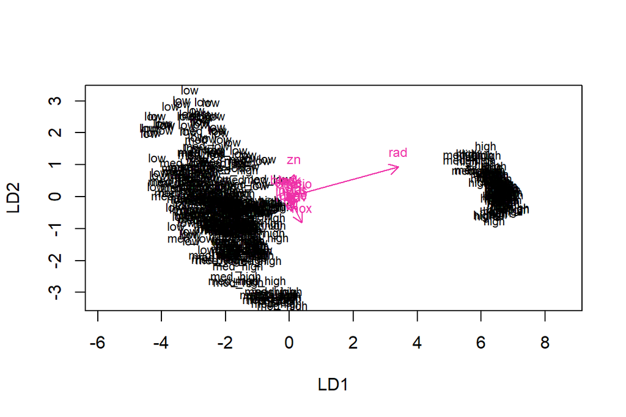

```r
# the function for lda biplot arrows
lda.arrows <- function(x, myscale = 1, arrow_heads = 0.1, color = "Maroon 2", tex = 0.75, choices = c(1,2)){
  heads <- coef(x)
  graphics::arrows(x0 = 0, y0 = 0,
         x1 = myscale * heads[,choices[1]],
         y1 = myscale * heads[,choices[2]], col=color, length = arrow_heads)
  text(myscale * heads[,choices], labels = row.names(heads),
       cex = tex, col=color, pos=3)
}

# target classes as numeric
classes <- as.numeric(train$crime)

# plot the lda results
plot(lda.fit, dimen = 2)
lda.arrows(lda.fit, myscale = 1)
```

## Predicting the classes with the model

We use the LDA model to predict ‘crime’ in the test data set:

```r
# save the correct classes from test data
correct_classes <- test$crime

# remove the crime variable from test data
test <- dplyr::select(test, -crime)

# predict classes with test data
lda.pred <- predict(lda.fit, newdata = test)

# Create the crosstabs
prediction_tab <- table(correct = correct_classes, predicted = lda.pred$class)

# Calculate the row-wise percentages
row_percentages <- apply(prediction_tab, 1, prop.table) * 100

# Print the table with row-wise percentages
prediction_tab
```

```
##           predicted
## correct    low med_low med_high high
##   low       16       6        2    0
##   med_low    5      20        5    0
##   med_high   0       8       17    2
##   high       0       0        0   21
```

```r
row_percentages
```

```
##           correct
## predicted        low  med_low  med_high high
##   low      66.666667 16.66667  0.000000    0
##   med_low  25.000000 66.66667 29.629630    0
##   med_high  8.333333 16.66667 62.962963    0
##   high      0.000000  0.00000  7.407407  100
```

## Distance measures with k-means analysis

```r
data("Boston")
summary(Boston)
```

```
##       crim                zn             indus            chas
##  Min.   : 0.00632   Min.   :  0.00   Min.   : 0.46   Min.   :0.00000
##  1st Qu.: 0.08205   1st Qu.:  0.00   1st Qu.: 5.19   1st Qu.:0.00000
##  Median : 0.25651   Median :  0.00   Median : 9.69   Median :0.00000
##  Mean   : 3.61352   Mean   : 11.36   Mean   :11.14   Mean   :0.06917
##  3rd Qu.: 3.67708   3rd Qu.: 12.50   3rd Qu.:18.10   3rd Qu.:0.00000
##  Max.   :88.97620   Max.   :100.00   Max.   :27.74   Max.   :1.00000
##       nox               rm             age              dis
##  Min.   :0.3850   Min.   :3.561   Min.   :  2.90   Min.   : 1.130
##  1st Qu.:0.4490   1st Qu.:5.886   1st Qu.: 45.02   1st Qu.: 2.100
##  Median :0.5380   Median :6.208   Median : 77.50   Median : 3.207
##  Mean   :0.5547   Mean   :6.285   Mean   : 68.57   Mean   : 3.795
##  3rd Qu.:0.6240   3rd Qu.:6.623   3rd Qu.: 94.08   3rd Qu.: 5.188
##  Max.   :0.8710   Max.   :8.780   Max.   :100.00   Max.   :12.127
##       rad              tax           ptratio          black
##  Min.   : 1.000   Min.   :187.0   Min.   :12.60   Min.   :  0.32
##  1st Qu.: 4.000   1st Qu.:279.0   1st Qu.:17.40   1st Qu.:375.38
##  Median : 5.000   Median :330.0   Median :19.05   Median :391.44
##  Mean   : 9.549   Mean   :408.2   Mean   :18.46   Mean   :356.67
##  3rd Qu.:24.000   3rd Qu.:666.0   3rd Qu.:20.20   3rd Qu.:396.23
##  Max.   :24.000   Max.   :711.0   Max.   :22.00   Max.   :396.90
##      lstat            medv
##  Min.   : 1.73   Min.   : 5.00
##  1st Qu.: 6.95   1st Qu.:17.02
##  Median :11.36   Median :21.20
##  Mean   :12.65   Mean   :22.53
##  3rd Qu.:16.95   3rd Qu.:25.00
##  Max.   :37.97   Max.   :50.00
```

```r
#scaling the dataset
boston_scaled <- scale(Boston)

# looks weird
str(boston_scaled)
```

```
##  num [1:506, 1:14] -0.419 -0.417 -0.417 -0.416 -0.412 ...
##  - attr(*, "dimnames")=List of 2
##   ..$ : chr [1:506] "1" "2" "3" "4" ...
##   ..$ : chr [1:14] "crim" "zn" "indus" "chas" ...
##  - attr(*, "scaled:center")= Named num [1:14] 3.6135 11.3636 11.1368 0.0692 0.5547 ...
##   ..- attr(*, "names")= chr [1:14] "crim" "zn" "indus" "chas" ...
##  - attr(*, "scaled:scale")= Named num [1:14] 8.602 23.322 6.86 0.254 0.116 ...
##   ..- attr(*, "names")= chr [1:14] "crim" "zn" "indus" "chas" ...
```

```r
# the scaled dataset needs to be a data frame for 'pairs' function to work
boston_scaled <- as.data.frame(boston_scaled)

# now it looks better..
str(boston_scaled)
```

```
## 'data.frame':    506 obs. of  14 variables:
##  $ crim   : num  -0.419 -0.417 -0.417 -0.416 -0.412 ...
##  $ zn     : num  0.285 -0.487 -0.487 -0.487 -0.487 ...
##  $ indus  : num  -1.287 -0.593 -0.593 -1.306 -1.306 ...
##  $ chas   : num  -0.272 -0.272 -0.272 -0.272 -0.272 ...
##  $ nox    : num  -0.144 -0.74 -0.74 -0.834 -0.834 ...
##  $ rm     : num  0.413 0.194 1.281 1.015 1.227 ...
##  $ age    : num  -0.12 0.367 -0.266 -0.809 -0.511 ...
##  $ dis    : num  0.14 0.557 0.557 1.077 1.077 ...
##  $ rad    : num  -0.982 -0.867 -0.867 -0.752 -0.752 ...
##  $ tax    : num  -0.666 -0.986 -0.986 -1.105 -1.105 ...
##  $ ptratio: num  -1.458 -0.303 -0.303 0.113 0.113 ...
##  $ black  : num  0.441 0.441 0.396 0.416 0.441 ...
##  $ lstat  : num  -1.074 -0.492 -1.208 -1.36 -1.025 ...
##  $ medv   : num  0.16 -0.101 1.323 1.182 1.486 ...
```

```r
# euclidean distance matrix
dist_eu <- dist(boston_scaled)

# look at the summary of the distances
summary(dist_eu)
```

```
##    Min. 1st Qu.  Median    Mean 3rd Qu.    Max.
##  0.1343  3.4625  4.8241  4.9111  6.1863 14.3970
```

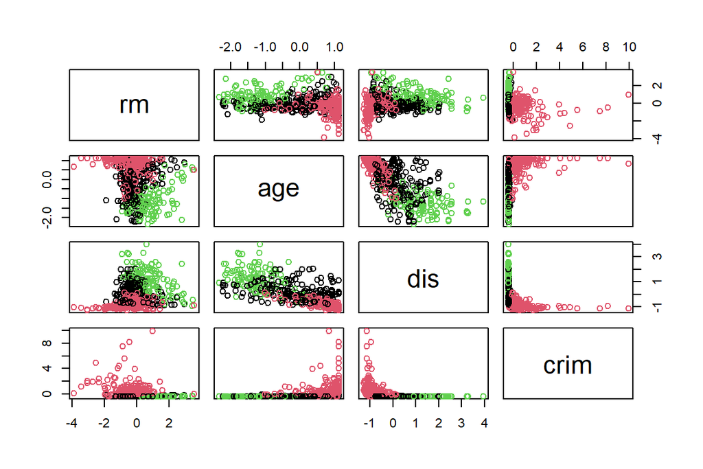

```r
# k-means clustering
km <- kmeans(boston_scaled, centers = 3)

# plot the Boston dataset with clusters
pairs(boston_scaled[c("rm", "age", "dis", "crim")], col = km$cluster)
```

In Exercise 4, the nonscaled ‘Boston’ data was used. In comparison to the exercise set, scaling the data did not change the outlook of the plots. it did change the scale to z-scores, representing how many standard deviations the observations are from the mean.

## The optimal number of clusters

An attempt on the first bonus task..:

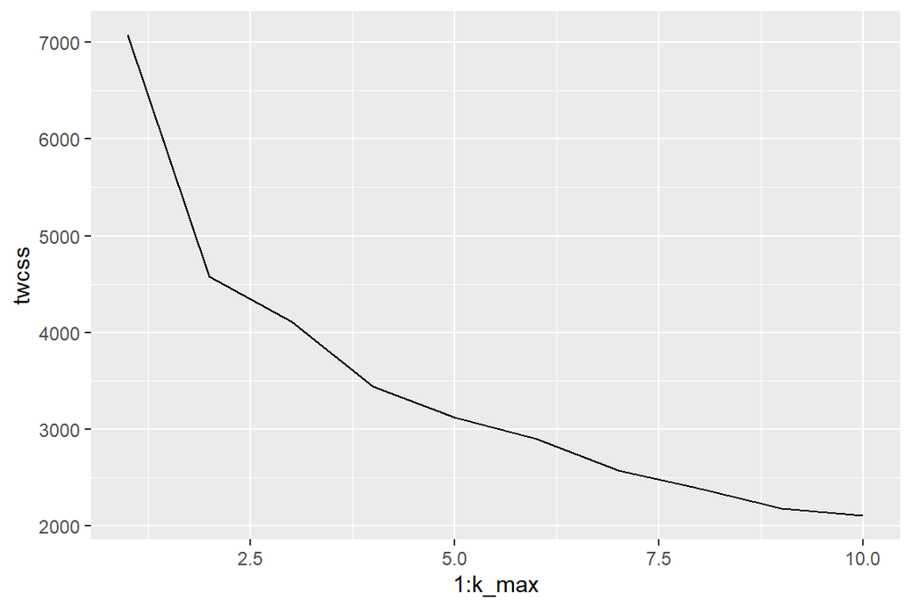

```r
library(ggplot2)
library(MASS)
data("Boston")

#scaling the data
boston_bonus <- scale(Boston)

# determine the number of clusters
k_max <- 10

# calculate the total within sum of squares
twcss <- sapply(1:k_max, function(k){kmeans(boston_scaled, k)$tot.withinss})

# visualize the results
qplot(x = 1:k_max, y = twcss, geom = 'line')
```

As the line drops drastically at 2, we use this for the optimum number of clusters

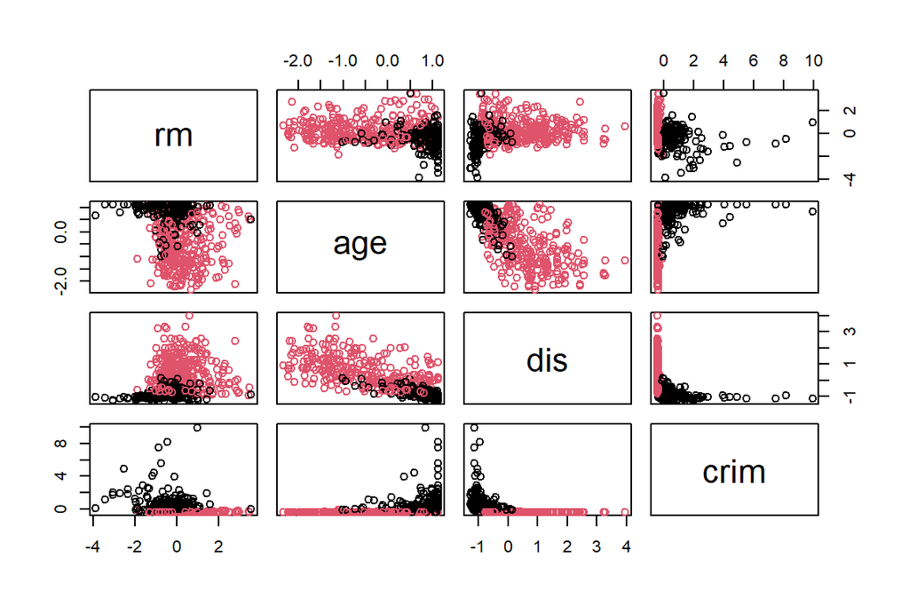

```r
# k-means clustering
km <- kmeans(boston_scaled, centers = 2)

# plot the Boston dataset with clusters
pairs(boston_scaled[c("rm", "age", "dis", "crim")], col = km$cluster)
```